# (Ford GoBike Analysis)

## Preliminary Wrangling

```python
# import all packages and set plots to be embedded inline
import numpy as np
import pandas as pd
import matplotlib.pyplot as plt
import seaborn as sb

%matplotlib inline
```

> I downoaded the version of the data from udaciy and read it into the notebook using the read_csv code

```python
df = pd.read_csv(r'C:\Users\SSJin\JIN\Crapbaskets\Data Analysis\5-Data Visualization\201902-fordgobike-tripdata.csv')
df.head()
```

|  | duration_sec | start_time | end_time | start_station_id | start_station_name | start_station_latitude | start_station_longitude | end_station_id | end_station_name | end_station_latitude | end_station_longitude | bike_id | user_type | member_birth_year | member_gender | bike_share_for_all_trip |
| --- | --- | --- | --- | --- | --- | --- | --- | --- | --- | --- | --- | --- | --- | --- | --- | --- |
| 0 | 52185 | 2019-02-28 17:32:10.1450 | 2019-03-01 08:01:55.9750 | 21.0 | Montgomery St BART Station (Market St at 2nd St) | 37.789625 | -122.400811 | 13.0 | Commercial St at Montgomery St | 37.794231 | -122.402923 | 4902 | Customer | 1984.0 | Male | No |
| 1 | 42521 | 2019-02-28 18:53:21.7890 | 2019-03-01 06:42:03.0560 | 23.0 | The Embarcadero at Steuart St | 37.791464 | -122.391034 | 81.0 | Berry St at 4th St | 37.775880 | -122.393170 | 2535 | Customer | NaN | NaN | No |
| 2 | 61854 | 2019-02-28 12:13:13.2180 | 2019-03-01 05:24:08.1460 | 86.0 | Market St at Dolores St | 37.769305 | -122.426826 | 3.0 | Powell St BART Station (Market St at 4th St) | 37.786375 | -122.404904 | 5905 | Customer | 1972.0 | Male | No |
| 3 | 36490 | 2019-02-28 17:54:26.0100 | 2019-03-01 04:02:36.8420 | 375.0 | Grove St at Masonic Ave | 37.774836 | -122.446546 | 70.0 | Central Ave at Fell St | 37.773311 | -122.444293 | 6638 | Subscriber | 1989.0 | Other | No |
| 4 | 1585 | 2019-02-28 23:54:18.5490 | 2019-03-01 00:20:44.0740 | 7.0 | Frank H Ogawa Plaza | 37.804562 | -122.271738 | 222.0 | 10th Ave at E 15th St | 37.792714 | -122.248780 | 4898 | Subscriber | 1974.0 | Male | Yes |

```python
df.info()
```

```
<class 'pandas.core.frame.DataFrame'>
RangeIndex: 183412 entries, 0 to 183411
Data columns (total 16 columns):
 #   Column                   Non-Null Count   Dtype
---  ------                   --------------   -----
 0   duration_sec             183412 non-null  int64
 1   start_time               183412 non-null  object
 2   end_time                 183412 non-null  object
 3   start_station_id         183215 non-null  float64
 4   start_station_name       183215 non-null  object
 5   start_station_latitude   183412 non-null  float64
 6   start_station_longitude  183412 non-null  float64
 7   end_station_id           183215 non-null  float64
 8   end_station_name         183215 non-null  object
 9   end_station_latitude     183412 non-null  float64
 10  end_station_longitude    183412 non-null  float64
 11  bike_id                  183412 non-null  int64
 12  user_type                183412 non-null  object
 13  member_birth_year        175147 non-null  float64
 14  member_gender            175147 non-null  object
 15  bike_share_for_all_trip  183412 non-null  object
dtypes: float64(7), int64(2), object(7)
memory usage: 22.4+ MB
```

```python
df.shape
```

```
(183412, 16)
```

```python
df.describe()
```

|  | duration_sec | start_station_id | start_station_latitude | start_station_longitude | end_station_id | end_station_latitude | end_station_longitude | bike_id | member_birth_year |
| --- | --- | --- | --- | --- | --- | --- | --- | --- | --- |
| count | 183412.000000 | 183215.000000 | 183412.000000 | 183412.000000 | 183215.000000 | 183412.000000 | 183412.000000 | 183412.000000 | 175147.000000 |
| mean | 726.078435 | 138.590427 | 37.771223 | -122.352664 | 136.249123 | 37.771427 | -122.352250 | 4472.906375 | 1984.806437 |
| std | 1794.389780 | 111.778864 | 0.099581 | 0.117097 | 111.515131 | 0.099490 | 0.116673 | 1664.383394 | 10.116689 |
| min | 61.000000 | 3.000000 | 37.317298 | -122.453704 | 3.000000 | 37.317298 | -122.453704 | 11.000000 | 1878.000000 |
| 25% | 325.000000 | 47.000000 | 37.770083 | -122.412408 | 44.000000 | 37.770407 | -122.411726 | 3777.000000 | 1980.000000 |
| 50% | 514.000000 | 104.000000 | 37.780760 | -122.398285 | 100.000000 | 37.781010 | -122.398279 | 4958.000000 | 1987.000000 |
| 75% | 796.000000 | 239.000000 | 37.797280 | -122.286533 | 235.000000 | 37.797320 | -122.288045 | 5502.000000 | 1992.000000 |
| max | 85444.000000 | 398.000000 | 37.880222 | -121.874119 | 398.000000 | 37.880222 | -121.874119 | 6645.000000 | 2001.000000 |

I will use the 'isnull' function to find the any missing data and clean it out if I judged reasonable.

```python
df.isnull().sum()
```

```
duration_sec                  0
start_time                    0
end_time                      0
start_station_id            197
start_station_name          197
start_station_latitude        0
start_station_longitude       0
end_station_id              197
end_station_name            197
end_station_latitude          0
end_station_longitude         0
bike_id                       0
user_type                     0
member_birth_year          8265
member_gender              8265
bike_share_for_all_trip       0
dtype: int64
```

```python
df_clean = df[df['member_gender'].isnull() == False]
df_clean.info()
```

```
<class 'pandas.core.frame.DataFrame'>
Int64Index: 175147 entries, 0 to 183411
Data columns (total 16 columns):
 #   Column                   Non-Null Count   Dtype
---  ------                   --------------   -----
 0   duration_sec             175147 non-null  int64
 1   start_time               175147 non-null  object
 2   end_time                 175147 non-null  object
 3   start_station_id         174952 non-null  float64
 4   start_station_name       174952 non-null  object
 5   start_station_latitude   175147 non-null  float64
 6   start_station_longitude  175147 non-null  float64
 7   end_station_id           174952 non-null  float64
 8   end_station_name         174952 non-null  object
 9   end_station_latitude     175147 non-null  float64
 10  end_station_longitude    175147 non-null  float64
 11  bike_id                  175147 non-null  int64
 12  user_type                175147 non-null  object
 13  member_birth_year        175147 non-null  float64
 14  member_gender            175147 non-null  object
 15  bike_share_for_all_trip  175147 non-null  object
dtypes: float64(7), int64(2), object(7)
memory usage: 22.7+ MB
```

```python
#removing rows where the start station id is not available
df_clean = df_clean[df_clean['start_station_id'].isnull() == False]
df_clean.info()
```

```
<class 'pandas.core.frame.DataFrame'>
Int64Index: 174952 entries, 0 to 183411
Data columns (total 16 columns):
 #   Column                   Non-Null Count   Dtype
---  ------                   --------------   -----
 0   duration_sec             174952 non-null  int64
 1   start_time               174952 non-null  object
 2   end_time                 174952 non-null  object
 3   start_station_id         174952 non-null  float64
 4   start_station_name       174952 non-null  object
 5   start_station_latitude   174952 non-null  float64
 6   start_station_longitude  174952 non-null  float64
 7   end_station_id           174952 non-null  float64
 8   end_station_name         174952 non-null  object
 9   end_station_latitude     174952 non-null  float64
 10  end_station_longitude    174952 non-null  float64
 11  bike_id                  174952 non-null  int64
 12  user_type                174952 non-null  object
 13  member_birth_year        174952 non-null  float64
 14  member_gender            174952 non-null  object
 15  bike_share_for_all_trip  174952 non-null  object
dtypes: float64(7), int64(2), object(7)
memory usage: 22.7+ MB
```

```python
#finding the genders of members and the count of each type
df_clean['member_gender'].value_counts()
```

```
Male      130500
Female     40805
Other       3647
Name: member_gender, dtype: int64
```

```python
#converting needed column values into a suitable type
df_clean.start_time = pd.to_datetime(df_clean.start_time)
df_clean.end_time = pd.to_datetime(df_clean.end_time)
```

```python
#finding the number of subscribers and customers
df_clean['user_type'].value_counts()
```

```
Subscriber    158386
Customer       16566
Name: user_type, dtype: int64
```

```python
#finding the stations with the highest and lowest rides starting from.
df_clean['start_station_id'].value_counts()
```

```
58.0     3649
67.0     3408
81.0     2952
21.0     2711
3.0      2620
         ...
234.0       9
51.0        7
224.0       4
300.0       3
344.0       2
Name: start_station_id, Length: 329, dtype: int64
```

```python
df_clean['start_station_name'].value_counts()
```

```
Market St at 10th St                                         3649
San Francisco Caltrain Station 2  (Townsend St at 4th St)    3408
Berry St at 4th St                                           2952
Montgomery St BART Station (Market St at 2nd St)             2711
Powell St BART Station (Market St at 4th St)                 2620
                                                             ...
Farnam St at Fruitvale Ave                                      9
Parker Ave at McAllister St                                     7
21st Ave at International Blvd                                  4
Palm St at Willow St                                            3
16th St Depot                                                   2
Name: start_station_name, Length: 329, dtype: int64
```

```python
#checking if there is any duplicated values
df_clean.duplicated().sum()
```

```
0
```

There is no duplicated values in the data

```python
df_clean.shape
```

```
(174952, 16)
```

```python
df_clean['bike_id'].value_counts()
```

```
4794    179
4814    172
5175    167
4450    166
5145    165
       ...
2194      1
1786      1
2042      1
5067      1
806       1
Name: bike_id, Length: 4607, dtype: int64
```

The 3 most used bikes are bike 4794, bike 4814, bike 5175.

```python
df_clean['member_birth_year'].value_counts()
```

```
1988.0    10214
1993.0     9323
1989.0     8967
1990.0     8640
1991.0     8484
          ...
1930.0        1
1910.0        1
1927.0        1
1928.0        1
1878.0        1
Name: member_birth_year, Length: 75, dtype: int64
```

There is more than 10k bikers born in 1988

```python
df_clean.groupby('member_gender')['member_birth_year'].value_counts()
```

```
member_gender  member_birth_year
Female         1990.0               2646
               1989.0               2505
               1988.0               2482
               1991.0               2460
               1992.0               2421
                                    ...
Other          1961.0                  2
               2000.0                  2
               1910.0                  1
               1928.0                  1
               1930.0                  1
Name: member_birth_year, Length: 175, dtype: int64
```

```python
#creating a new column for the actual age of the people in this data.
df_clean['member_age'] = 2019 - df_clean['member_birth_year']
```

```python
#creating a new column for trips duration in minutes instead of seconds
df_clean['duration_min'] = df_clean['duration_sec']/60
```

```python
#Now removing the duration in seconds column since I won't have a need for it
df_clean.drop('duration_sec', axis=1, inplace=True)
```

```python
#converting the age and birth year into integer
df_clean['member_age'] = df_clean['member_age'].astype(int)
df_clean['member_birth_year'] = df_clean['member_birth_year'].astype(int)
```

```python
#creating columns for starting date, hour, day, month, and year
df_clean['start_date'] = df_clean.start_time.dt.strftime('%Y-%m-%d')
df_clean['start_hour'] = df_clean.start_time.dt.strftime('%H')
df_clean['start_day'] = df_clean.start_time.dt.strftime('%A')
df_clean['start_month'] =  df_clean.start_time.dt.strftime('%B')
df_clean['year'] = df_clean.start_time.dt.strftime('%Y')
```

```python
df_clean['start_month'].nunique()
```

```
1
```

```python
print(df_clean['start_month'].value_counts())
print(df_clean['year'].value_counts())
```

```
February    174952
Name: start_month, dtype: int64
2019    174952
Name: year, dtype: int64
```

Since the data includes only values from the same month (February) and year (2019) for start time, their columns can be dropped

```python
df_clean.drop(['start_month', 'year'], axis=1, inplace=True)
```

```python
df_clean['start_hour']=df_clean['start_hour'].astype(int)
```

```python
#creating columns for ending date, hour, day, month, and year
df_clean['end_date'] = df_clean.end_time.dt.strftime('%Y-%m-%d')
df_clean['end_hour'] = df_clean.end_time.dt.strftime('%H')
df_clean['end_day'] = df_clean.end_time.dt.strftime('%A')
df_clean['end_month'] =  df_clean.end_time.dt.strftime('%B')
```

```python
df_clean.shape
```

```
(174952, 24)
```

```python
df_clean.head()
```

|  | start_time | end_time | start_station_id | start_station_name | start_station_latitude | start_station_longitude | end_station_id | end_station_name | end_station_latitude | end_station_longitude | ... | bike_share_for_all_trip | member_age | duration_min | start_date | start_hour | start_day | end_date | end_hour | end_day | end_month |
| --- | --- | --- | --- | --- | --- | --- | --- | --- | --- | --- | --- | --- | --- | --- | --- | --- | --- | --- | --- | --- | --- |
| 0 | 2019-02-28 17:32:10.145 | 2019-03-01 08:01:55.975 | 21.0 | Montgomery St BART Station (Market St at 2nd St) | 37.789625 | -122.400811 | 13.0 | Commercial St at Montgomery St | 37.794231 | -122.402923 | ... | No | 35 | 869.750000 | 2019-02-28 | 17 | Thursday | 2019-03-01 | 08 | Friday | March |
| 2 | 2019-02-28 12:13:13.218 | 2019-03-01 05:24:08.146 | 86.0 | Market St at Dolores St | 37.769305 | -122.426826 | 3.0 | Powell St BART Station (Market St at 4th St) | 37.786375 | -122.404904 | ... | No | 47 | 1030.900000 | 2019-02-28 | 12 | Thursday | 2019-03-01 | 05 | Friday | March |
| 3 | 2019-02-28 17:54:26.010 | 2019-03-01 04:02:36.842 | 375.0 | Grove St at Masonic Ave | 37.774836 | -122.446546 | 70.0 | Central Ave at Fell St | 37.773311 | -122.444293 | ... | No | 30 | 608.166667 | 2019-02-28 | 17 | Thursday | 2019-03-01 | 04 | Friday | March |
| 4 | 2019-02-28 23:54:18.549 | 2019-03-01 00:20:44.074 | 7.0 | Frank H Ogawa Plaza | 37.804562 | -122.271738 | 222.0 | 10th Ave at E 15th St | 37.792714 | -122.248780 | ... | Yes | 45 | 26.416667 | 2019-02-28 | 23 | Thursday | 2019-03-01 | 00 | Friday | March |
| 5 | 2019-02-28 23:49:58.632 | 2019-03-01 00:19:51.760 | 93.0 | 4th St at Mission Bay Blvd S | 37.770407 | -122.391198 | 323.0 | Broadway at Kearny | 37.798014 | -122.405950 | ... | No | 60 | 29.883333 | 2019-02-28 | 23 | Thursday | 2019-03-01 | 00 | Friday | March |

5 rows × 24 columns

### What is/are the main feature(s) of interest in your dataset?

> My area of focus will be the duration of the rides!

### What features in the dataset do you think will help support your investigation into your feature(s) of interest?

> start time columns. member_birth_year, member_age. member_gender. user_type

## Univariate Exploration

> The target of this area is to visualize the distribution of the duration of the trips, members' age, starting hour and days, members' genders, members' type, stations, and the busiest station

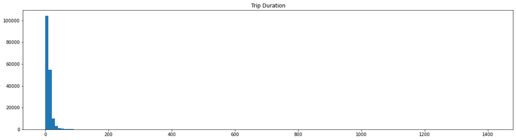

```python
binsize = 10
bins = np.arange(0, df_clean['duration_min'].max()+binsize, binsize)

plt.figure(figsize=[20, 5])
plt.title('Trip Duration')

plt.hist(data = df_clean, x = 'duration_min', bins=bins);
```

Apparently most of the data is below 50 this should indicate abnoramlity in distribution

```python
df_clean['duration_min'].describe()
```

```
count    174952.000000
mean         11.733379
std          27.370082
min           1.016667
25%           5.383333
50%           8.500000
75%          13.150000
max        1409.133333
Name: duration_min, dtype: float64
```

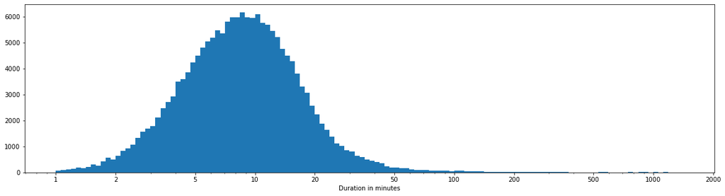

```python
log_binsize = 0.025
bins = 10 ** np.arange(0, np.log10(df_clean['duration_min'].max())+log_binsize, log_binsize)

plt.figure(figsize=[20, 5]);
plt.hist(data = df_clean, x = 'duration_min', bins = bins);
plt.xscale('log');
plt.xticks([1, 2, 5, 10, 20, 50, 100, 200, 500, 1000, 2000], [1, 2, 5, 10, 20, 50, 100, 200, 500, 1000, 2000]);
plt.xlabel('Duration in minutes');
```

Moving on to member's ages

```python
df_clean['member_age'].describe()
```

```
count    174952.000000
mean         34.196865
std          10.118731
min          18.000000
25%          27.000000
50%          32.000000
75%          39.000000
max         141.000000
Name: member_age, dtype: float64
```

We can see that the max age is 141 which isn't helpful in this case

```python
df_clean = df_clean[df_clean['member_age'] <= 60]
```

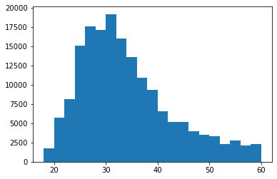

```python
binsize = 2
bins = np.arange(18, df_clean['member_age'].max()+binsize, binsize)
plt.hist(data = df_clean, x = 'member_age', bins = bins);
```

Obviously most of the bikers are near the age of 30. the bikers' age increases gradually to their thirties then it decreases

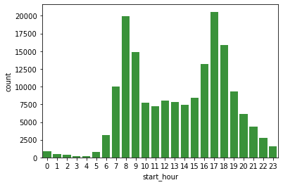

```python
color=  sb.color_palette()[2]
sb.countplot(data = df_clean, x = 'start_hour', color = color);
```

from the plot we can see that 08:00 and 17:00 are the two hours when most of the rides start.

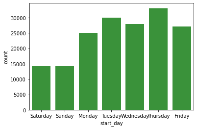

```python
day_order=['Saturday', 'Sunday', 'Monday', 'Tuesday', 'Wednesday', 'Thursday', 'Friday']
sb.countplot(data = df_clean, x = 'start_day', color = color, order=day_order);
```

The most busy days for bikers are Thursday, Tuesday, and Wednesday.

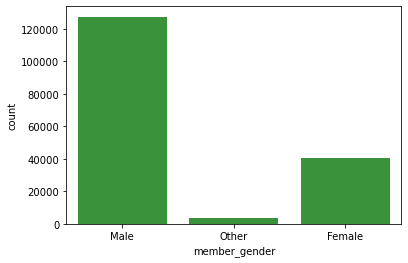

```python
sb.countplot(data = df_clean, x = 'member_gender', color = color);
```

Male is the dominant gender for bikers with approximately 3 times the ratio of females

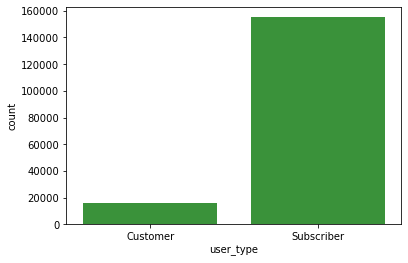

```python
sb.countplot(data = df_clean, x = 'user_type', color = color);
```

In case of users condition most of the bikers are subscribers.

```python
df_clean.start_station_id.value_counts(sort=True)
```

```
58.0     3626
67.0     3314
81.0     2880
21.0     2667
3.0      2568
         ...
301.0       8
51.0        7
224.0       4
300.0       3
344.0       2
Name: start_station_id, Length: 329, dtype: int64
```

```python
df_max_station = df_clean[df_clean.start_station_id == 58.0]
```

```python
df_max_station['start_station_name'].head(1)
```

```
38    Market St at 10th St
Name: start_station_name, dtype: object
```

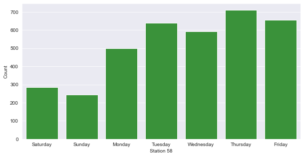

```python
plt.rcParams['figure.figsize'] = 10, 5
sb.set_style('darkgrid')

sb.countplot(data=df_max_station, x='start_day', color=color, order=day_order);
plt.xlabel('Station 58');
plt.ylabel('Count');
```

The days that have most starting from traffic in the station of Market St at 10th St are Thursday, Friday, and Tuesday.

### Discuss the distribution(s) of your variable(s) of interest. Were there any unusual points? Did you need to perform any transformations?

> I found that there is a relation between the number of bike rides and the days where certain days of the week have more bike traffic than others. There is also trend toward starting the bikes either at the early morning (8 o'colck) or the evening (5 o'clock) which is obvoiusly related to working schedules. Also there is the fact that people strongly tend to subscribe than just being casual customer.

### Of the features you investigated, were there any unusual distributions? Did you perform any operations on the data to tidy, adjust, or change the form of the data? If so, why did you do this?

> The age of the customers didn't consider the fact that some people will be dead by the year 2019 that's why I got a biker's age of 141, therefore I had to clip the data to include only people less than 60 years old.

## Bivariate Exploration

> In this section I will plot the relation between the duration of trips and Age, Members' gender, Members' type.

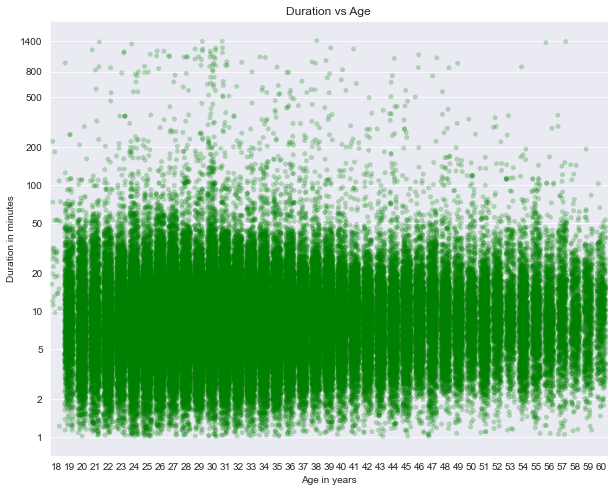

```python
plt.figure(figsize=[10,8])
sb.stripplot((df_clean['member_age']), df_clean['duration_min'], jitter=0.35, alpha = 0.25,color='green')

plt.title('Duration vs Age')
plt.xlabel('Age in years')
plt.yscale('log');
plt.yticks([1, 2, 5, 10, 20, 50, 100, 200, 500, 800, 1400], [1, 2, 5, 10, 20, 50, 100, 200, 500, 800, 1400])
plt.ylabel('Duration in minutes')
plt.show();
```

As can be seen there is a slight decline in the trend as the bikers get older their duration of trips on the bike decreases

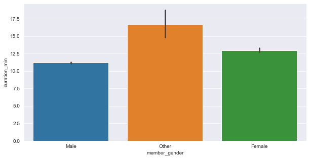

```python
sb.barplot(x='member_gender', y='duration_min', data=df_clean);
```

From the plot we can say that as a cumulative the gender other has a higher trip duration than female and male respectively.

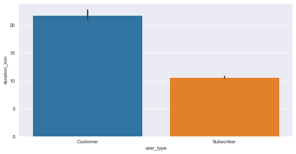

```python
sb.barplot(x='user_type', y='duration_min', data=df_clean);
```

### Talk about some of the relationships you observed in this part of the investigation. How did the feature(s) of interest vary with other features in the dataset?

> In case of the users' type customers spent more time on the bikes than the subscribers. the Other gender time is greater than time achieved by males or females. The duration decreases as the riders gets older

### Did you observe any interesting relationships between the other features (not the main feature(s) of interest)?

> Nothing really caught my attention!

## Multivariate Exploration

> This time we will examine the relation that the trip duration has with two other variables.

#### Trip Duration vs Gender vs Age

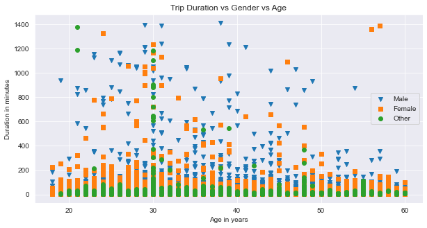

```python
m_gender = [['Male', 'v'],['Female', 's'],['Other', 'o']]

for gender, marker in m_gender:
    df_gender = df_clean[df_clean['member_gender'] == gender]
    plt.scatter((df_gender['member_age']), df_gender['duration_min'], marker = marker, alpha= 1)
plt.legend(['Male','Female','Other'])

plt.title('Trip Duration vs Gender vs Age')
plt.xlabel('Age in years')
plt.ylabel('Duration in minutes')
plt.show();
```

the plot is a little jammed so let's sperate the genders into different plots

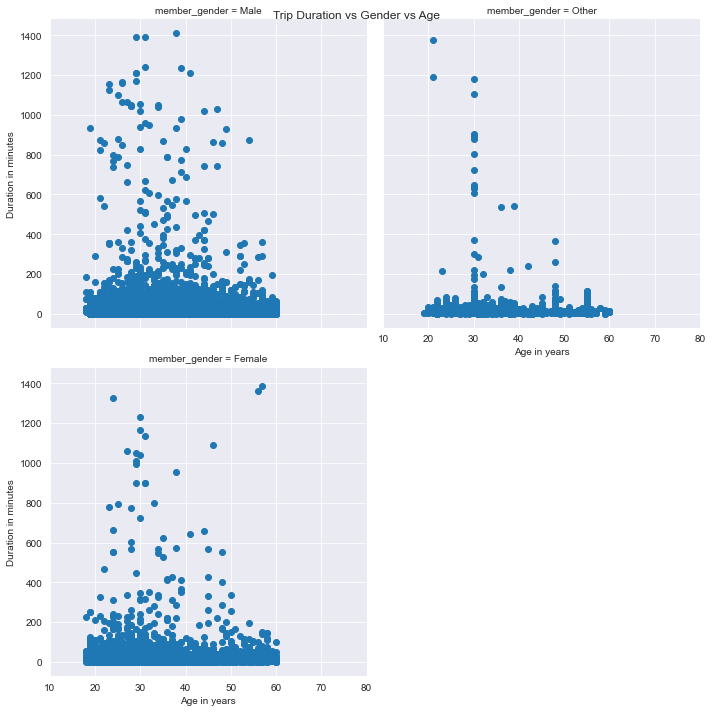

```python
sep_gender = sb.FacetGrid(data = df_clean, col = 'member_gender', col_wrap = 2, size = 5,
                 xlim = [10, 80])
sep_gender.map(plt.scatter, 'member_age', 'duration_min', alpha= 1)


sep_gender.set_xlabels('Age in years')
sep_gender.set_ylabels('Duration in minutes')
sep_gender.fig.suptitle('Trip Duration vs Gender vs Age')
plt.show();
```

#### Trip Duration vs User Type vs Age

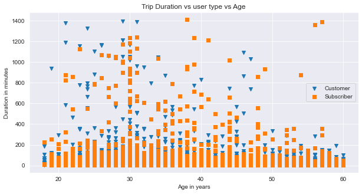

```python
m_usertype = [['Customer', 'v'],['Subscriber', 's']]

for utype, marker in m_usertype:
    df_utype = df_clean[df_clean['user_type'] == utype]
    plt.scatter((df_utype['member_age']), df_utype['duration_min'], marker = marker, alpha= 1)
plt.legend(['Customer','Subscriber'])
plt.title('Trip Duration vs user type vs Age')
plt.xlabel('Age in years')
plt.ylabel('Duration in minutes')
plt.show();
```

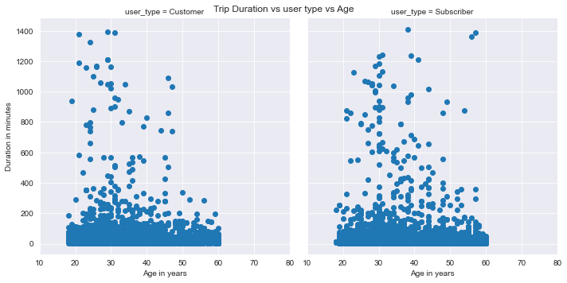

```python
user_type = sb.FacetGrid(data = df_clean, col = 'user_type', col_wrap = 2, size = 5,
                 xlim = [10, 80])
user_type.map(plt.scatter, 'member_age', 'duration_min', alpha= 1)

user_type.set_xlabels('Age in years')
user_type.set_ylabels('Duration in minutes')
user_type.fig.suptitle('Trip Duration vs user type vs Age')
plt.show();
```

for the case of gender difference, there is obvious similarity between male and female throughout the years. while the trend in others is different. for type of users same trend is seen with users ride durations declining as they get older.

### Talk about some of the relationships you observed in this part of the investigation. Were there features that strengthened each other in terms of looking at your feature(s) of interest?

> I noted that in the case of others there is no long trips as they get older, which is not that severe in case of the older men and women.

### Were there any interesting or surprising interactions between features?

> Again there isn't anything that significant!

```python
df_clean.to_csv('Ford_GoBike_master_file.csv', index=False)
```